# Practical Machine Learning - Prediction Assignment Writeup

Jag Padala

Jun 18, 2015

In this project we will utilize several machine learning techniques to predict the behavior of users of fitness tracker equipment.

## Exploratory Analysis

Let us do some exploratory analysis to get a basic understanding of the data set

```r
suppressWarnings(library(ggplot2))
suppressWarnings(library(caret))
setwd("/Users/apadala/Coursera/pml")
traindata <- read.csv("pml-training.csv")
testdata <- read.csv("pml-testing.csv")

set.seed(1234)

inTrainPml <- createDataPartition(y=traindata$classe,p=0.6,list=FALSE)
trainingPml <- traindata[inTrainPml,]
testingPml <- traindata[-inTrainPml,]

summary(trainingPml)
```

```
##        X            user_name    raw_timestamp_part_1 raw_timestamp_part_2
##  Min.   :    2   adelmo  :2327   Min.   :1.322e+09    Min.   :   294
##  1st Qu.: 4936   carlitos:1881   1st Qu.:1.323e+09    1st Qu.:258646
##  Median : 9794   charles :2147   Median :1.323e+09    Median :496316
##  Mean   : 9808   eurico  :1878   Mean   :1.323e+09    Mean   :501632
##  3rd Qu.:14708   jeremy  :1985   3rd Qu.:1.323e+09    3rd Qu.:752362
##  Max.   :19621   pedro   :1558   Max.   :1.323e+09    Max.   :998750
##
##           cvtd_timestamp new_window    num_window    roll_belt
##  5/12/11 11:24   : 904   no :11540   Min.   :  1   Min.   :-28.90
##  28/11/2011 14:14: 898   yes:  236   1st Qu.:221   1st Qu.:  1.11
##  5/12/11 11:25   : 860               Median :421   Median :114.00
##  30/11/2011 17:11: 857               Mean   :430   Mean   : 64.50
##  2/12/11 14:57   : 846               3rd Qu.:644   3rd Qu.:123.00
##  5/12/11 14:23   : 828               Max.   :864   Max.   :162.00
##  (Other)         :6583
##    pitch_belt          yaw_belt       total_accel_belt kurtosis_roll_belt
##  Min.   :-55.8000   Min.   :-179.00   Min.   : 0.00             :11540
##  1st Qu.:  1.8275   1st Qu.: -88.30   1st Qu.: 3.00    #DIV/0!  :    8
##  Median :  5.2900   Median : -12.60   Median :17.00    -0.01685 :    1
##  Mean   :  0.3029   Mean   : -11.15   Mean   :11.32    -0.025513:    1
##  3rd Qu.: 15.0000   3rd Qu.:  13.10   3rd Qu.:18.00    -0.033935:    1
##  Max.   : 60.3000   Max.   : 179.00   Max.   :28.00    -0.06016 :    1
##                                                        (Other)  :  224
##  kurtosis_picth_belt kurtosis_yaw_belt skewness_roll_belt
##           :11540            :11540              :11540
##  #DIV/0!  :   23     #DIV/0!:  236     #DIV/0!  :    7
##  -0.15095 :    3                       -0.003095:    1
##  -2.060105:    3                       -0.010002:    1
##  11.094417:    3                       -0.01402 :    1
##  -0.684748:    2                       -0.015465:    1
##  (Other)  :  202                       (Other)  :  225
##  skewness_roll_belt.1 skewness_yaw_belt max_roll_belt     max_picth_belt
##           :11540             :11540     Min.   :-94.300   Min.   : 3.00
##  #DIV/0!  :   23      #DIV/0!:  236     1st Qu.:-87.900   1st Qu.: 5.00
##  0        :    4                        Median : -4.900   Median :18.00
##  -0.189082:    2                        Mean   : -4.565   Mean   :13.34
##  -0.587156:    2                        3rd Qu.: 19.175   3rd Qu.:19.25
##  -1.159179:    2                        Max.   :177.000   Max.   :30.00
##  (Other)  :  203                        NA's   :11540     NA's   :11540
```

[output cut: 305 more lines]

```
##  Min.   :-498.00   Min.   :-595.0   Min.   :-446.00   Min.   :-1280.0
##  1st Qu.:-179.00   1st Qu.:  57.0   1st Qu.:-181.00   1st Qu.: -618.0
##  Median : -57.00   Median : 201.0   Median : -36.00   Median : -387.5
##  Mean   : -63.01   Mean   : 163.8   Mean   : -53.56   Mean   : -313.9
##  3rd Qu.:  76.00   3rd Qu.: 312.0   3rd Qu.:  27.00   3rd Qu.:  -75.0
##  Max.   : 359.00   Max.   : 923.0   Max.   : 285.00   Max.   :  672.0
##
##  magnet_forearm_y magnet_forearm_z classe
##  Min.   :-896.0   Min.   :-973     A:3348
##  1st Qu.:  -1.0   1st Qu.: 185     B:2279
##  Median : 587.0   Median : 507     C:2054
##  Mean   : 378.7   Mean   : 391     D:1930
##  3rd Qu.: 736.0   3rd Qu.: 652     E:2165
##  Max.   :1450.0   Max.   :1090
##
```

We loaded the data and created a training and test dataset. From the summary we can see that there are 159 predictors in the data for predicting the value of the classe. We can see that classe is a categorical variable with 5 possible results.

We can also see that we have measured the movements for 6 users over a period of time. The timestamp for the measurements and the window of the measurements are recorded. Since the users were instructed to deliberately perform some good and some bad repitions we need to make sure there is no target leakage by including measurements such as window and timestamp that would ovefit our model and lead to incorrect predictions.

We then need to start looking at various other measurements that were taken.

### DATA CLEAN UP

```r
trainingPmlNonNACols <- trainingPml[c("roll_belt","pitch_belt","yaw_belt","total_accel_belt","gyros_belt_x","gyros_belt_y","gyros_belt_z","accel_belt_x","accel_belt_y","accel_belt_z","magnet_belt_x","magnet_belt_y","magnet_belt_z","roll_arm","pitch_arm","yaw_arm","total_accel_arm","gyros_arm_x","gyros_arm_y","gyros_arm_z","accel_arm_x","accel_arm_y","accel_arm_z","magnet_arm_x","magnet_arm_y","magnet_arm_z","roll_dumbbell","pitch_dumbbell","yaw_dumbbell","total_accel_dumbbell","gyros_dumbbell_x","gyros_dumbbell_y","gyros_dumbbell_z","accel_dumbbell_x","accel_dumbbell_y","accel_dumbbell_z","magnet_dumbbell_x","magnet_dumbbell_y","magnet_dumbbell_z","roll_forearm","pitch_forearm","yaw_forearm","total_accel_forearm","gyros_forearm_x","gyros_forearm_y","gyros_forearm_z","accel_forearm_x","accel_forearm_y","accel_forearm_z","magnet_forearm_x","magnet_forearm_y","magnet_forearm_z","classe")]

testingPmlNonNACols <- testingPml[c("roll_belt","pitch_belt","yaw_belt","total_accel_belt","gyros_belt_x","gyros_belt_y","gyros_belt_z","accel_belt_x","accel_belt_y","accel_belt_z","magnet_belt_x","magnet_belt_y","magnet_belt_z","roll_arm","pitch_arm","yaw_arm","total_accel_arm","gyros_arm_x","gyros_arm_y","gyros_arm_z","accel_arm_x","accel_arm_y","accel_arm_z","magnet_arm_x","magnet_arm_y","magnet_arm_z","roll_dumbbell","pitch_dumbbell","yaw_dumbbell","total_accel_dumbbell","gyros_dumbbell_x","gyros_dumbbell_y","gyros_dumbbell_z","accel_dumbbell_x","accel_dumbbell_y","accel_dumbbell_z","magnet_dumbbell_x","magnet_dumbbell_y","magnet_dumbbell_z","roll_forearm","pitch_forearm","yaw_forearm","total_accel_forearm","gyros_forearm_x","gyros_forearm_y","gyros_forearm_z","accel_forearm_x","accel_forearm_y","accel_forearm_z","magnet_forearm_x","magnet_forearm_y","magnet_forearm_z","classe")]
```

Now that we have cleaned up the data we can start fitting various models and see how the models perform

### Model Training 1

Trees : We will first fit a tree model using the rpart package in caret. We will analyze the accuracy of the prediction for the model

```r
 modfitRpart <- train(classe ~.,method="rpart",data=trainingPmlNonNACols)
 modfitRpart$finalModel
```

```
## n= 11776
##
## node), split, n, loss, yval, (yprob)
##       * denotes terminal node
##
##  1) root 11776 8428 A (0.28 0.19 0.17 0.16 0.18)
##    2) roll_belt< 130.5 10774 7436 A (0.31 0.21 0.19 0.18 0.11)
##      4) pitch_forearm< -34.55 919    2 A (1 0.0022 0 0 0) *
##      5) pitch_forearm>=-34.55 9855 7434 A (0.25 0.23 0.21 0.2 0.12)
##       10) magnet_dumbbell_y< 436.5 8314 5944 A (0.29 0.18 0.24 0.19 0.11)
##         20) roll_forearm< 122.5 5137 3022 A (0.41 0.18 0.18 0.17 0.061) *
##         21) roll_forearm>=122.5 3177 2124 C (0.08 0.18 0.33 0.23 0.18) *
##       11) magnet_dumbbell_y>=436.5 1541  743 B (0.033 0.52 0.039 0.23 0.18) *
##    3) roll_belt>=130.5 1002   10 E (0.01 0 0 0 0.99) *
```

```r
  library(rattle)
```

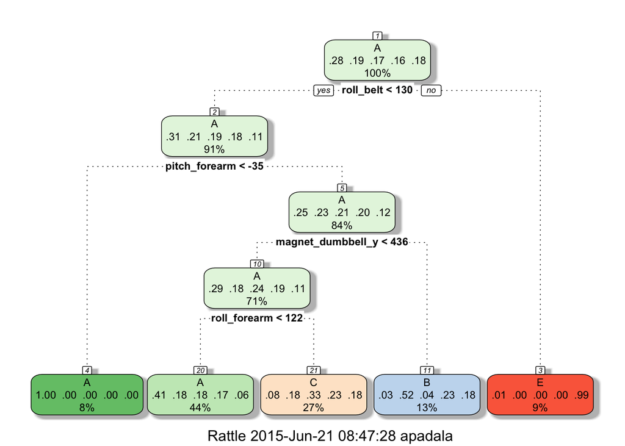

```r
  fancyRpartPlot(modfitRpart$finalModel)
```

```r
  modfitRpart
```

```
## CART
##
## 11776 samples
##    52 predictor
##     5 classes: 'A', 'B', 'C', 'D', 'E'
##
## No pre-processing
## Resampling: Bootstrapped (25 reps)
##
## Summary of sample sizes: 11776, 11776, 11776, 11776, 11776, 11776, ...
##
## Resampling results across tuning parameters:
##
##   cp          Accuracy   Kappa       Accuracy SD  Kappa SD
##   0.03618889  0.5232124  0.38448962  0.02470143   0.03890642
##   0.06110584  0.4018777  0.18592797  0.06028161   0.09852178
##   0.11651637  0.3320531  0.07413223  0.04188912   0.06186040
##
## Accuracy was used to select the optimal model using  the largest value.
## The final value used for the model was cp = 0.03618889.
```

As we can see the accuracy is pretty poor. However the model does give us some insight into some of the significant variables such as roll_belt, pitch_forearm, magnet_dumbbell_y and roll_forearm that seem to have a higher relevance to predict the outcome for classe.

Since the accuracy of predictions is only 52% the our of sample error rate would be unacceptable.

### Model Training 2

The next model we will try out is the random forest. This may be a better choice for this kind of data since random forest models are good for data with a large number of variables. It estimates the variables that are important so we can get a fairly accurate idea of the variables used for the end result

```r
modfitRforest <- train(classe ~.,method="rf",data=trainingPmlNonNACols)
print(modfitRforest)
```

```
## Random Forest
##
## 11776 samples
##    52 predictor
##     5 classes: 'A', 'B', 'C', 'D', 'E'
##
## No pre-processing
## Resampling: Bootstrapped (25 reps)
##
## Summary of sample sizes: 11776, 11776, 11776, 11776, 11776, 11776, ...
##
## Resampling results across tuning parameters:
##
##   mtry  Accuracy   Kappa      Accuracy SD  Kappa SD
##    2    0.9870336  0.9835895  0.001655951  0.002103040
##   27    0.9868318  0.9833367  0.001919397  0.002427099
##   52    0.9787137  0.9730624  0.005580349  0.007067277
##
## Accuracy was used to select the optimal model using  the largest value.
## The final value used for the model was mtry = 2.
```

```r
print(modfitRforest$finalModel)
```

```
##
## Call:
##  randomForest(x = x, y = y, mtry = param$mtry)
##                Type of random forest: classification
##                      Number of trees: 500
## No. of variables tried at each split: 2
##
##         OOB estimate of  error rate: 0.87%
## Confusion matrix:
##      A    B    C    D    E class.error
## A 3343    2    0    2    1 0.001493429
## B   21 2252    6    0    0 0.011847301
## C    0   20 2028    6    0 0.012658228
## D    0    0   34 1894    2 0.018652850
## E    0    1    2    6 2156 0.004157044
```

```r
varImp(modfitRforest)
```

```
## rf variable importance
##
##   only 20 most important variables shown (out of 52)
##
##                      Overall
## roll_belt             100.00
## yaw_belt               83.40
## magnet_dumbbell_z      69.36
## magnet_dumbbell_y      66.25
## pitch_belt             61.15
## pitch_forearm          59.75
## magnet_dumbbell_x      55.72
## roll_forearm           51.97
## magnet_belt_z          48.42
## accel_belt_z           48.28
## roll_dumbbell          43.96
## accel_dumbbell_y       42.59
## magnet_belt_y          42.27
## accel_dumbbell_z       39.35
## roll_arm               35.14
## accel_forearm_x        31.29
## yaw_dumbbell           30.36
## total_accel_dumbbell   29.57
## accel_dumbbell_x       28.94
## magnet_forearm_z       28.08
```

### Description of the sample error and estimation of the error with cross validation

As we can see the accuracy of the model fit is pretty high at 98.7% with the internal test data that random forest uses within the 60% of data we provided for the model. The out of box error rate is estimated at .87%. The number of trees used were 500 with optimal mtry at 2.

We now test the model against the 40% of the original data that we resreved to be test data.

```r
 confusionMatrix(testingPmlNonNACols$classe,predict(modfitRforest,testingPmlNonNACols))
```

```
## Confusion Matrix and Statistics
##
##           Reference
## Prediction    A    B    C    D    E
##          A 2231    1    0    0    0
##          B   10 1506    2    0    0
##          C    0   12 1352    4    0
##          D    0    0   30 1255    1
##          E    0    0    2    3 1437
##
## Overall Statistics
##
##                Accuracy : 0.9917
##                  95% CI : (0.9895, 0.9936)
##     No Information Rate : 0.2856
##     P-Value [Acc > NIR] : < 2.2e-16
##
##                   Kappa : 0.9895
##  Mcnemar's Test P-Value : NA
##
## Statistics by Class:
##
##                      Class: A Class: B Class: C Class: D Class: E
## Sensitivity            0.9955   0.9914   0.9755   0.9945   0.9993
## Specificity            0.9998   0.9981   0.9975   0.9953   0.9992
## Pos Pred Value         0.9996   0.9921   0.9883   0.9759   0.9965
## Neg Pred Value         0.9982   0.9979   0.9948   0.9989   0.9998
## Prevalence             0.2856   0.1936   0.1767   0.1608   0.1833
## Detection Rate         0.2843   0.1919   0.1723   0.1600   0.1832
## Detection Prevalence   0.2845   0.1935   0.1744   0.1639   0.1838
## Balanced Accuracy      0.9977   0.9948   0.9865   0.9949   0.9993
```

The tests show an accuracy of 99.17 with a 95% confidence interval between 98.9% to 99.36 %. Based on this the estimated sample error rate is 0.83% which is slighty better than the out of box error estimated by using the training data set.

Predictions for the Coursera Test data

Once the models are complete we run the tests against the test data set provided by Coursera

```r
testPmlNonNACols <- testdata[c("roll_belt","pitch_belt","yaw_belt","total_accel_belt","gyros_belt_x","gyros_belt_y","gyros_belt_z","accel_belt_x","accel_belt_y","accel_belt_z","magnet_belt_x","magnet_belt_y","magnet_belt_z","roll_arm","pitch_arm","yaw_arm","total_accel_arm","gyros_arm_x","gyros_arm_y","gyros_arm_z","accel_arm_x","accel_arm_y","accel_arm_z","magnet_arm_x","magnet_arm_y","magnet_arm_z","roll_dumbbell","pitch_dumbbell","yaw_dumbbell","total_accel_dumbbell","gyros_dumbbell_x","gyros_dumbbell_y","gyros_dumbbell_z","accel_dumbbell_x","accel_dumbbell_y","accel_dumbbell_z","magnet_dumbbell_x","magnet_dumbbell_y","magnet_dumbbell_z","roll_forearm","pitch_forearm","yaw_forearm","total_accel_forearm","gyros_forearm_x","gyros_forearm_y","gyros_forearm_z","accel_forearm_x","accel_forearm_y","accel_forearm_z","magnet_forearm_x","magnet_forearm_y","magnet_forearm_z")]
courseraTestResults <- predict( modfitRforest,testPmlNonNACols)
courseraTestResults
```

```
##  [1] B A B A A E D B A A B C B A E E A B B B
## Levels: A B C D E
```

### Fine tuning the random forest

Randon forest does not need any additional cross validation but it is possible to fine tune training model by using a k fold cross validation for the data. Since this is more computing intensive the original sample traning data did not execute on the current hardware within a reasonable amount of time (60 minutes). So I created a smaller sample size to pass to the trainer.

```r
set.seed(1234)

inTrainPml10 <- createDataPartition(y=traindata$classe,p=0.3,list=FALSE)
trainingPml10 <- traindata[inTrainPml10,]
testingPml10 <- traindata[-inTrainPml10,]

trainingPmlNonNACols10 <- trainingPml10[c("roll_belt","pitch_belt","yaw_belt","total_accel_belt","gyros_belt_x","gyros_belt_y","gyros_belt_z","accel_belt_x","accel_belt_y","accel_belt_z","magnet_belt_x","magnet_belt_y","magnet_belt_z","roll_arm","pitch_arm","yaw_arm","total_accel_arm","gyros_arm_x","gyros_arm_y","gyros_arm_z","accel_arm_x","accel_arm_y","accel_arm_z","magnet_arm_x","magnet_arm_y","magnet_arm_z","roll_dumbbell","pitch_dumbbell","yaw_dumbbell","total_accel_dumbbell","gyros_dumbbell_x","gyros_dumbbell_y","gyros_dumbbell_z","accel_dumbbell_x","accel_dumbbell_y","accel_dumbbell_z","magnet_dumbbell_x","magnet_dumbbell_y","magnet_dumbbell_z","roll_forearm","pitch_forearm","yaw_forearm","total_accel_forearm","gyros_forearm_x","gyros_forearm_y","gyros_forearm_z","accel_forearm_x","accel_forearm_y","accel_forearm_z","magnet_forearm_x","magnet_forearm_y","magnet_forearm_z","classe")]

testingPmlNonNACols10 <- testingPml10[c("roll_belt","pitch_belt","yaw_belt","total_accel_belt","gyros_belt_x","gyros_belt_y","gyros_belt_z","accel_belt_x","accel_belt_y","accel_belt_z","magnet_belt_x","magnet_belt_y","magnet_belt_z","roll_arm","pitch_arm","yaw_arm","total_accel_arm","gyros_arm_x","gyros_arm_y","gyros_arm_z","accel_arm_x","accel_arm_y","accel_arm_z","magnet_arm_x","magnet_arm_y","magnet_arm_z","roll_dumbbell","pitch_dumbbell","yaw_dumbbell","total_accel_dumbbell","gyros_dumbbell_x","gyros_dumbbell_y","gyros_dumbbell_z","accel_dumbbell_x","accel_dumbbell_y","accel_dumbbell_z","magnet_dumbbell_x","magnet_dumbbell_y","magnet_dumbbell_z","roll_forearm","pitch_forearm","yaw_forearm","total_accel_forearm","gyros_forearm_x","gyros_forearm_y","gyros_forearm_z","accel_forearm_x","accel_forearm_y","accel_forearm_z","magnet_forearm_x","magnet_forearm_y","magnet_forearm_z","classe")]

testPmlNonNACols <- testdata[c("roll_belt","pitch_belt","yaw_belt","total_accel_belt","gyros_belt_x","gyros_belt_y","gyros_belt_z","accel_belt_x","accel_belt_y","accel_belt_z","magnet_belt_x","magnet_belt_y","magnet_belt_z","roll_arm","pitch_arm","yaw_arm","total_accel_arm","gyros_arm_x","gyros_arm_y","gyros_arm_z","accel_arm_x","accel_arm_y","accel_arm_z","magnet_arm_x","magnet_arm_y","magnet_arm_z","roll_dumbbell","pitch_dumbbell","yaw_dumbbell","total_accel_dumbbell","gyros_dumbbell_x","gyros_dumbbell_y","gyros_dumbbell_z","accel_dumbbell_x","accel_dumbbell_y","accel_dumbbell_z","magnet_dumbbell_x","magnet_dumbbell_y","magnet_dumbbell_z","roll_forearm","pitch_forearm","yaw_forearm","total_accel_forearm","gyros_forearm_x","gyros_forearm_y","gyros_forearm_z","accel_forearm_x","accel_forearm_y","accel_forearm_z","magnet_forearm_x","magnet_forearm_y","magnet_forearm_z")]

modfitRforest10 <- train(classe ~.,method="rf",data=trainingPmlNonNACols10,
        trControl=trainControl(method="cv",number=10, repeats=2, verboseIter = TRUE), prox=TRUE)
print(modfitRforest10)
```

```
## Random Forest
##
## 5889 samples
##   52 predictor
##    5 classes: 'A', 'B', 'C', 'D', 'E'
##
## No pre-processing
## Resampling: Cross-Validated (10 fold)
##
## Summary of sample sizes: 5301, 5301, 5300, 5301, 5298, 5300, ...
##
## Resampling results across tuning parameters:
##
##   mtry  Accuracy   Kappa      Accuracy SD  Kappa SD
##    2    0.9779269  0.9720659  0.008125489  0.010289454
##   27    0.9787749  0.9731428  0.006700520  0.008476131
##   52    0.9706244  0.9628343  0.008157182  0.010318391
##
## Accuracy was used to select the optimal model using  the largest value.
## The final value used for the model was mtry = 27.
```

```r
print(modfitRforest10$finalModel)
```

```
##
## Call:
##  randomForest(x = x, y = y, mtry = param$mtry, proximity = TRUE)
##                Type of random forest: classification
##                      Number of trees: 500
## No. of variables tried at each split: 27
##
##         OOB estimate of  error rate: 1.83%
## Confusion matrix:
##      A    B    C   D    E class.error
## A 1668    4    0   1    1 0.003584229
## B   21 1106    9   3    1 0.029824561
## C    0   15 1002  10    0 0.024342746
## D    0    1   21 940    3 0.025906736
## E    0    6    5   7 1065 0.016620499
```

```r
confusionMatrix(testingPmlNonNACols10$classe,predict(modfitRforest10,testingPmlNonNACols10))
```

```
## Confusion Matrix and Statistics
##
##           Reference
## Prediction    A    B    C    D    E
##          A 3888   14    1    2    1
##          B   44 2563   48    1    1
##          C    0   39 2340   16    0
##          D    0    2   64 2184    1
##          E    0    8   13   24 2479
##
## Overall Statistics
##
##                Accuracy : 0.9797
##                  95% CI : (0.9772, 0.982)
##     No Information Rate : 0.2863
##     P-Value [Acc > NIR] : < 2.2e-16
##
##                   Kappa : 0.9743
##  Mcnemar's Test P-Value : 7.765e-15
##
## Statistics by Class:
##
##                      Class: A Class: B Class: C Class: D Class: E
## Sensitivity            0.9888   0.9760   0.9489   0.9807   0.9988
## Specificity            0.9982   0.9915   0.9951   0.9942   0.9960
## Pos Pred Value         0.9954   0.9646   0.9770   0.9702   0.9822
## Neg Pred Value         0.9955   0.9943   0.9889   0.9963   0.9997
## Prevalence             0.2863   0.1912   0.1796   0.1622   0.1807
## Detection Rate         0.2831   0.1866   0.1704   0.1590   0.1805
## Detection Prevalence   0.2844   0.1935   0.1744   0.1639   0.1838
## Balanced Accuracy      0.9935   0.9838   0.9720   0.9874   0.9974
```

```r
courseraTestResults <- predict( modfitRforest10,testPmlNonNACols)
courseraTestResults
```

```
##  [1] B A B A A E D B A A B C B A E E A B B B
## Levels: A B C D E
```

### Final results for the tweaked model

With a sample size of 0.3 of the origial the k fold cross validation completes in a reasonable amount of time. The accuracy is 97.97 on the target with an out of box error estimate of 1.83%. The results on the coursera test cases however achieve a 100% target and it yields the same results.

With more processing power it may be possible to use more of the dataset to generate a higher accuracy with k fold cross validation. The default cross validation built into the random forests routine seems to be doing a fine job as is.